# Combining Models

Paul Povel

2024-12-03

```r
# Loading necessary libraries for decision tree modeling and evaluation
library(C50)
library(caret)
```

In this step, we combine the results of multiple predictive models into an ensemble model. The individual models we have previously worked on include:

1. Artificial Neural Network (ANN)
2. k-Nearest Neighbors (KNN)
3. Logistic Regression
4. Decision Tree
5. Random Forest
6. Support Vector Machine (SVM)

These models have been used to predict whether a hotel booking will be canceled. By combining their predictions into a single dataset and using a decision tree model to classify the results, we aim to leverage the strengths of each model to improve overall predictive accuracy.

## Step 1: Load Predictions

```r
# Load predictions from individual models
ann_predictions <- read.csv("prediction_ANN.csv")
knn_predictions <- read.csv("knn_prediction.csv")
logistic_predictions <- read.csv("prediction_logistic_regression.csv")
tree_predictions <- read.csv("prediction_decision_tree.csv")
random_forest_predictions <- read.csv("prediction_random_forest.csv")
svm_predictions <- read.csv("prediction_svm.csv")
```

## Step 2: Combine Predictions

```r
# Combine model predictions into a single data frame for ensemble modeling
ensemble_df <- data.frame(
  ANN_Model = ann_predictions$V1,
  KNN_Model = knn_predictions$x,
  Logistic_Model = logistic_predictions$x,
  Decision_Tree = tree_predictions$x,
  Random_Forest = random_forest_predictions$x,
  SVM = svm_predictions$x,
  booking_status = 0
)

# Load the cleaned dataset and extract the true booking status
clnd <- read.csv("cleaned.csv")
set.seed(12345)

# Perform a 70:30 split for testing
split_size <- 0.3
test_size <- split_size * nrow(clnd)
test_rows <- sample(1:nrow(clnd), test_size)

# Create test data
book_test <- clnd[test_rows, ]
ensemble_df$booking_status <- as.factor(book_test$booking.status)

# Summarize the combined data
summary(ensemble_df)
```

```
##    ANN_Model        KNN_Model      Logistic_Model    Decision_Tree
##  Min.   :0.0000   Min.   :0.0000   Min.   :0.00000   Min.   :0.0000
##  1st Qu.:0.0000   1st Qu.:0.0000   1st Qu.:0.06594   1st Qu.:0.0000
##  Median :0.0000   Median :0.0000   Median :0.22368   Median :0.0000
##  Mean   :0.2698   Mean   :0.2793   Mean   :0.33083   Mean   :0.3026
##  3rd Qu.:1.0000   3rd Qu.:1.0000   3rd Qu.:0.56566   3rd Qu.:1.0000
##  Max.   :1.0000   Max.   :1.0000   Max.   :0.99964   Max.   :1.0000
##  Random_Forest        SVM         booking_status
##  Min.   :0.000   Min.   :0.0000   0:7330
##  1st Qu.:0.000   1st Qu.:0.0000   1:3555
##  Median :0.000   Median :0.0000
##  Mean   :0.276   Mean   :0.2692
##  3rd Qu.:1.000   3rd Qu.:1.0000
##  Max.   :1.000   Max.   :1.0000
```

## Step 3: Split Data for Ensemble Model

```r
# Split data into training and testing sets
split_size <- 0.3
test_size <- split_size * nrow(ensemble_df)
# Set seed for reproducibility
set.seed(12345)
test_rows <- sample(1:nrow(ensemble_df), test_size)

ensemble_test <- ensemble_df[test_rows, ]
ensemble_train <- ensemble_df[-test_rows, ]
```

## Step 4: Train Decision Tree with Cost Matrix

To account for the different costs associated with prediction errors, we implement a cost matrix. In our hotel scenario:

- A **false positive** (predicting a cancellation when there isn’t one) costs $\$100$ because we would have to rebook the guest at another hotel at our expense.
- A **false negative** (predicting no cancellation when there is one) costs $\$20$ due to the opportunity cost of losing the potential profit from renting out the room to someone else.

### Cost Calculation

The false negative cost is derived as:

$$\text{Cost of False Negative} = \text{Average Price per Night} \times
\text{Profit Margin}$$

For our hotel:
$$\text{Cost of False Negative} = \$100 \times 0.20 = \$20$$

```r
# Define a cost matrix based on the costs of false positives and false negatives
cost_matrix <- matrix(c(0, 100, 20, 0), nrow = 2)

# Train a decision tree model using the cost matrix
final_tree_model <- C5.0(as.factor(booking_status) ~ ., data = ensemble_train, costs = cost_matrix)
```

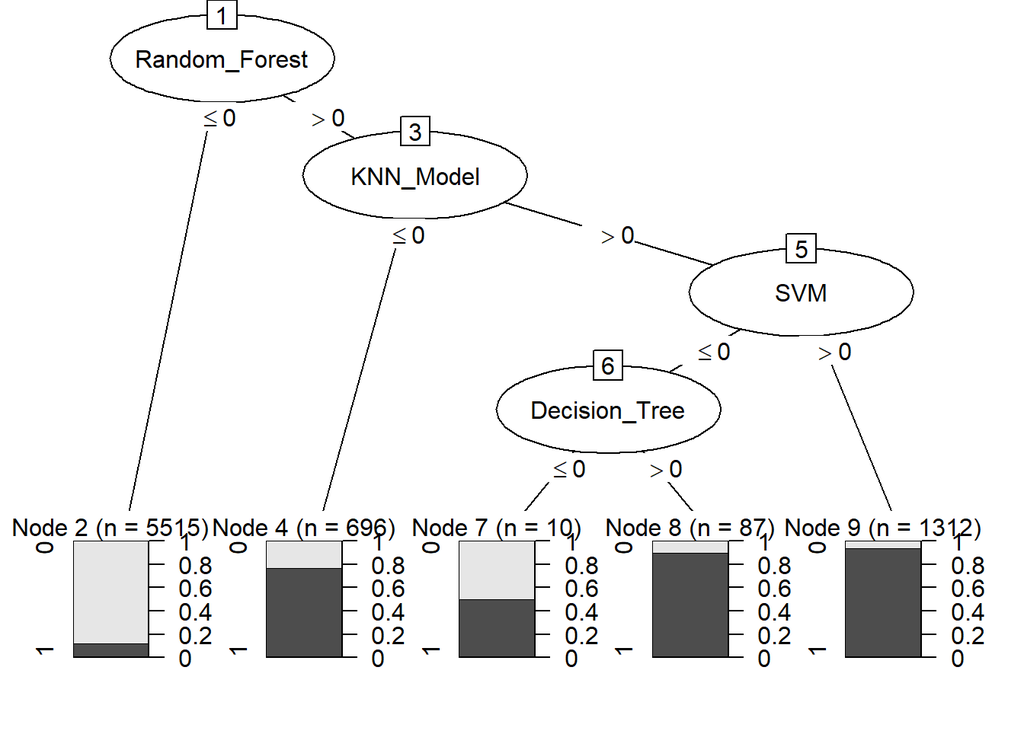

```r
# Plot the decision tree structure
plot(final_tree_model)
```

## Step 5: Evaluate the Ensemble Model

```r
# Make predictions on the test dataset
final_predictions <- predict(final_tree_model, ensemble_test)

# Evaluate the model's performance using a confusion matrix
conf_matrix <- confusionMatrix(final_predictions, ensemble_test$booking_status, positive = "1")

# Print the confusion matrix and performance statistics
print(conf_matrix)
```

```
## Confusion Matrix and Statistics
##
##           Reference
## Prediction    0    1
##          0 2170  510
##          1   39  546
##
##                Accuracy : 0.8319
##                  95% CI : (0.8186, 0.8445)
##     No Information Rate : 0.6766
##     P-Value [Acc > NIR] : < 2.2e-16
##
##                   Kappa : 0.5652
##
##  Mcnemar's Test P-Value : < 2.2e-16
##
##             Sensitivity : 0.5170
##             Specificity : 0.9823
##          Pos Pred Value : 0.9333
##          Neg Pred Value : 0.8097
##              Prevalence : 0.3234
##          Detection Rate : 0.1672
##    Detection Prevalence : 0.1792
##       Balanced Accuracy : 0.7497
##
##        'Positive' Class : 1
##
```